# Simulations for `norm_glsx_aic_sim.R`

# System setup

```r
R <- list.files(path = "./simulations/R", pattern = "*.R", full.names = TRUE)
sapply(R, source, .GlobalEnv)
library(knitr)
library(kableExtra)
```

# Setting

## Data

Following Wang *et al.* (2012) with one-hundred replications, the correlated normal responses are generated from the model
$$y_{ij} = \mathbf{X}_{ij}^{\top}\boldsymbol{\beta}
+ \varepsilon_{ij},$$
where $i = 1, \ldots, 200,$ $j = 1, \ldots, 4,$ $\mathbf{X}_{ij} = (x_{ij, 1}, \ldots, x_{ij, 6})^{\top},$ and $\boldsymbol{\beta} = (2.0, 3.0, 0.5, 0.0, 0.0, 0.0)^{\top}.$

- For the covariates,
  - $x_{ij,1}$ was generated from the Bernoulli(0.5) distribution, and
  - $x_{ij,2}$ to $x_{ij,6}$ from the multivariate normal distribution with mean 0 and an AR(1) covariance matrix with marginal variance 1 and auto-correlation coefficient 0.5.
- The random errors $(\varepsilon_{i1}, \ldots, \varepsilon_{i4})^{\top}$ are generated from the multivariate normal distribution with marginal mean 0, marginal variance 1, and an exchangeable correlation matrix with $\rho = 0.5$.

## Transformation of the response and covariate matrix

After the data was simulated, the response, $\mathbf{y},$ and the covariate matrix, $\mathbf{X},$ was transformed by:

1. fitting a fully saturated model with an unstructured working correlation matrix,
2. calculating $\mathbf{V}_{i} = \phi \mathbf{A}_{i}^{1/2}\mathbf{R}_{i}(\boldsymbol{\alpha})\mathbf{A}_{i}^{1/2}$ and finding $\mathbf{V}_{i}^{-1/2}$, and
3. obtaining $\mathbf{y}^{*} = \mathbf{V}_{i}^{-1/2}\mathbf{y}$ and $\mathbf{X}^{*} = \mathbf{V}_{i}^{-1/2}\mathbf{X}$.

## Best subsets

Using the transformed response and covariate matrix, all $2^6 - 1 = 63$ the subsets of the fully saturated model were fit using generlized linear models (GLMs). Then, the model resulting with the minimum AIC and BIC value were selected as the best fitting models.

```r
nsims <- 100L
beta <- c(2.0, 3.0, 0.5, 0.0, 0.0, 0.0)
w <- which(beta != 0)
l <- length(w)
```

# Results

The simulations results are stored in:

```r
load("./simulations/outputs/norm_glsx_aic_sim/norm_glsx_aic_sim.RData")
```

## Information criterions across the simulations

Now for each of the models with the minimum AIC and BIC, the information criteria values will be broken into their parts to see what is impacting the selection process. Additionally, this provides a look at the stability of the information criterions across the simulations. After the transformation of the response vector and covariate matrix, the observations of the response should be independent. Thus, the goodness-of-fit term will be a product a traditional likelihood unlike QIC, QICu and BQICu. Note that AIC and BIC are the likelihood variants of QICu and BQICu. See `norm_glsx_bqicu_sim` for more information on QICu and BQICu.

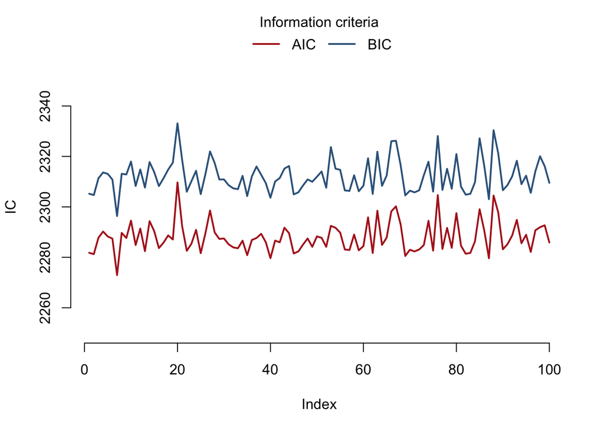

```r
aic <- sapply(res_aic, function(x) {x$aic_min}, simplify = TRUE)
bic <- sapply(res_bic, function(x) {x$bic_min}, simplify = TRUE)

plot(
    x = seq_len(nsims), y = aic,
    ylim = c(2250, 2350),
    xlab = "Index", ylab = "IC",
    type = "l", lwd = 2, col = "firebrick",
    bty = "n",
)
lines(
    x = seq_len(nsims), y = bic,
    col = "steelblue4", lwd = 2
)
legend_top(
    legend = c("AIC", "BIC"),
    col = c("firebrick", "steelblue4"),
    lwd = 2, lty = 1, title = "Information criteria"
)
```

### Goodness-of-fit

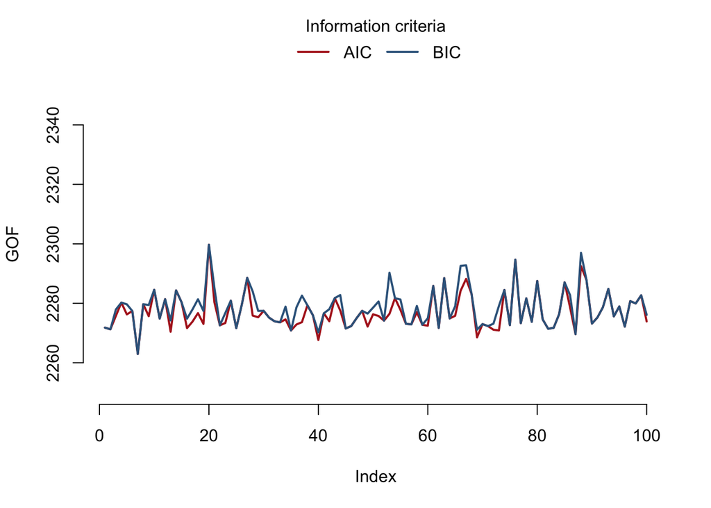

```r
gof_aic <- rep(NA, nsims)
gof_bic <- rep(NA, nsims)
for (k in seq_len(nsims)) {
    w1 <- res_aic[[k]]$min
    w2 <- res_bic[[k]]$min
    gof_aic[k] <- res_aic[[k]]$gof[w1]
    gof_bic[k] <- res_bic[[k]]$gof[w2]
}

plot(
    x = seq_len(nsims), y = gof_aic,
    ylim = c(2250, 2350),
    xlab = "Index", ylab = "GOF",
    type = "l", lwd = 2, col = "firebrick",
    bty = "n",
)
lines(
    x = seq_len(nsims), y = gof_bic,
    col = "steelblue4", lwd = 2
)
legend_top(
    legend = c("AIC", "BIC"),
    col = c("firebrick", "steelblue4"),
    lwd = 2, lty = 1, title = "Information criteria"
)
```

### Penalty

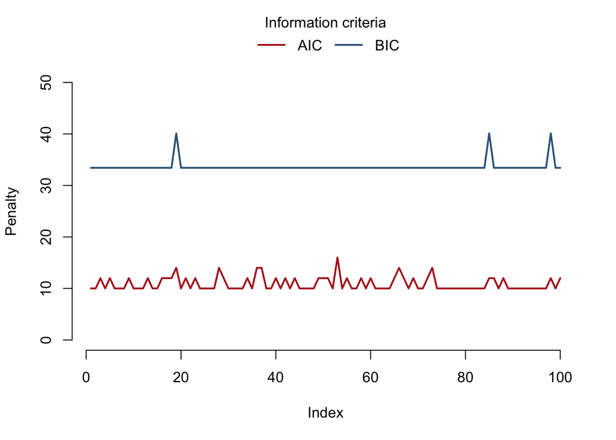

```r
penalty_aic <- rep(NA, nsims)
penalty_bic <- rep(NA, nsims)
for (k in seq_len(nsims)) {
    w1 <- res_aic[[k]]$min
    w2 <- res_bic[[k]]$min
    penalty_aic[k] <- res_aic[[k]]$penalty[w1]
    penalty_bic[k] <- res_bic[[k]]$penalty[w2]
}

plot(
    x = seq_len(nsims), y = penalty_aic,
    ylim = c(0, 50),
    xlab = "Index", ylab = "Penalty",
    type = "l", lwd = 2, col = "firebrick",
    bty = "n",
)
lines(
    x = seq_len(nsims), y = penalty_bic,
    col = "steelblue4", lwd = 2
)
legend_top(
    legend = c("AIC", "BIC"),
    col = c("firebrick", "steelblue4"),
    lwd = 2, lty = 1, title = "Information criteria"
)
```

## Feature selection based on AIC and BIC

For measuring the overall performance based on each working correlation structure, a function will be created called `look` that reports the number of models, where

- the number of features selected is less than the number of non-zero coefficients in the generating model (`under`),
- only the non-zero features from the generating model were selected (`exact`),
- the number of features selected matches the number of non-zero coefficients in the generating model; however, at least one of the selected features is NOT one of the non-zero effects in the generating model (i.e., `mis`),
- the number of features selected is greated than the number of non-zero coefficients in the generating model (`over`), and
- the number of features selected is greated than the number of non-zero coefficients in the generating model and include all the non-zero effects (`over_inc`).

```r
# creating a function to generate a look at the simulation results
look <- function(x) {
    under <- 0
    exact <- 0
    mis <- 0
    over <- 0
    over_inc <- 0
    for (k in seq_len(nsims)) {
        under <- under + (length(x[[k]]$vars) < l)
        exact <- exact + identical(x[[k]]$vars, w)
        mis <- mis + (!identical(x[[k]]$vars, w) & (length(x[[k]]$vars) == l))
        over <- over + (length(x[[k]]$vars) > l)
        over_inc <- over_inc + ((length(x[[k]]$vars) > l) & all(w %in% x[[k]]$vars))
    }
    return(
        data.frame(
            under = under, exact = exact,
            mis = mis, over = over,
            over_inc = over_inc
        )
    )
}
```

Using the `look` function, we have the following summary measures from the simulation set, where the models resulting in the minimum AIC and BIC values were selected as the best fitting model for each working correlation structure.

```r
data.frame(
    ic = c("AIC", "BIC"),
    dplyr::bind_rows(look(res_aic), look(res_bic))
)
```

```
##    ic under exact mis over over_inc
## 1 AIC     0    64   0   36       36
## 2 BIC     0    97   0    3        3
```